# automatic-ticket-classification-case-study-nlp - CHATGPT

Automatic Ticket Classification

Create a model to automatically classify customer complaints based on the products and services mentioned in the support tickets. By automating the classification process, the financial company can route the tickets to the correct department, improving efficiency and customer satisfaction.

## Problem Statement

Customer complaints are crucial for financial companies, as they highlight shortcomings in products or services. Addressing these complaints quickly and effectively reduces customer dissatisfaction and enhances loyalty. Moreover, analyzing these complaints helps the company identify areas for service improvement.

However, customer complaints are typically unstructured text data. As the company grows, manually categorizing each support ticket to the relevant department becomes increasingly cumbersome. This case study will involve automating this process using NLP techniques to improve the company's ticket classification system.

In this project, you will be working as an NLP engineer for a financial company offering products such as credit cards, bank accounts, and mortgages. The objective is to develop a system that classifies customer complaints into categories based on the products and services mentioned.

## Business Goal

Your goal is to build a model that can automatically classify customer complaints into relevant categories. This will help route the complaints to the appropriate department, allowing for faster resolution of issues and improved customer satisfaction.

The solution will involve **Non-Negative Matrix Factorization (NMF)** for topic modeling, which will help identify patterns and recurring words in the tickets. These patterns will allow you to cluster tickets into relevant categories.

The five categories for classification are:

1. **Credit card / Prepaid card**
2. **Bank account services**
3. **Theft/Dispute reporting**
4. **Mortgages/Loans**
5. **Others**

After clustering the complaints using NMF, you will be able to use this information to train a supervised model (e.g., logistic regression, decision tree, random forest) to automatically classify new complaints into the correct department.

## Steps to be Followed

To complete this assignment, follow the eight major tasks outlined below:

### 1. **Data Loading**

- Load the `.json` data containing customer complaints provided by the company.
- Ensure the data is correctly parsed and formatted for further processing.

### 2. **Text Preprocessing**

- Clean the text data by removing irrelevant characters, stopwords, and applying techniques such as stemming or lemmatization.
- Ensure the text is in a consistent format for the next stages.

### 3. **Exploratory Data Analysis (EDA)**

- Perform an initial analysis of the text data to understand the distribution of complaints.
- Visualize the data to explore patterns, common words, and potential topics.
- Identify any missing values or issues that need addressing in the dataset.

### 4. **Feature Extraction**

- Convert the cleaned text into numerical features using techniques like **TF-IDF (Term Frequency-Inverse Document Frequency)** or **Count Vectorization**.
- This step prepares the data for topic modeling and classification.

### 5. **Topic Modelling**

- Apply **Non-Negative Matrix Factorization (NMF)** to uncover latent topics from the text data.
- Analyze the topics to understand the common themes and categorize customer complaints into relevant groups.
- Use the resulting topic clusters to group the tickets into the five predefined categories.

### 6. **Model Building Using Supervised Learning**

- Based on the topic modeling results, build a classification model to predict the appropriate department for each customer complaint.
- Choose from algorithms like **Logistic Regression**, **Decision Tree**, or **Random Forest** for model building.

### 7. **Model Training and Evaluation**

- Split the dataset into training and testing sets.
- Train the model using the training set and evaluate its performance on the testing set using metrics such as accuracy, precision, recall, and F1 score.

### 8. **Model Inference**

- Once the model is trained and evaluated, use it to classify new customer complaint tickets automatically.
- Test the model's ability to generalize to unseen data and ensure its practical applicability in real-world scenarios.

## Conclusion

By following these steps, you will develop a robust system for automatically classifying customer complaints based on their content. This solution will streamline the customer support process and allow the company to address customer issues more effectively and efficiently.

```python
from IPython.display import display, SVG
from IPython.display import HTML

# From SVG string
svg_content = """
<svg xmlns="http://www.w3.org/2000/svg" viewBox="0 0 800 600" xmlns:v="https://vecta.io/nano"><style><![CDATA[.B{font-family:Arial}.C{stroke-width:2}.D{font-size:10px}.E{stroke:#3a0ca3}.F{fill:#fff}.G{text-anchor:middle}.H{stroke-width:3}.I{fill:#3a0ca3}.J{fill:#7209b7}.K{fill:#f72585}.L{font-family:monospace}.M{fill:#4cc9f0}.N{fill:#4361ee}.O{stroke:#4361ee}.P{font-weight:bold}.Q{stroke-dasharray:10 5}]]></style><path fill="#f0f6ff" d="M0 0h800v600H0z"/><g fill="#e2eaff"><circle cx="100" cy="80" r="30"/><circle cx="700" cy="150" r="50"/><circle cx="120" cy="500" r="60"/><circle cx="680" cy="520" r="40"/></g><text x="400" y="60" font-size="30" class="B G N P">AI Ticket Classification</text><text x="400" y="90" fill="#4895ef" font-size="18" class="B G">Banking Customer Support</text><g transform="matrix(1.1 0 0 1.1 400 320)"><rect width="140" height="110" x="-70" y="-120" rx="20" class="E H M"/><circle cx="-30" cy="-80" r="15" class="C E F"/><circle cx="30" cy="-80" r="15" class="C E F"/><circle cx="-30" cy="-80" r="7" class="I"/><circle cx="30" cy="-80" r="7" class="I"/><path fill="none" stroke-linecap="round" d="M-30-50q30 20 60 0" class="E H"/><path d="M-40-120v-20" class="E H"/><circle cx="-40" cy="-145" r="8" class="K"/><path d="M40-120v-20" class="E H"/><circle cx="40" cy="-145" r="8" class="K"/><path d="M-15-10h30v20h-30z" class="C E J"/><rect width="120" height="100" x="-60" y="10" rx="10" class="E H N"/><rect width="80" height="60" x="-40" y="30" fill="#b5c7ff" rx="5" class="C E"/><circle cx="-20" cy="50" r="8" class="K"/><circle cy="50" r="8" class="M"/><circle cx="20" cy="50" r="8" class="J"/><rect width="60" height="10" x="-30" y="70" rx="3" class="I"/><circle cy="-85" r="30" opacity=".1" class="K"><animate attributeName="opacity" dur="3s" repeatCount="indefinite" values="0.15;0.3;0.15"/></circle></g><g transform="translate(120 250)"><rect width="140" height="180" rx="10" class="C F O"/><rect width="140" height="180" x="-5" y="-5" opacity=".7" rx="10" class="C F O"/><rect width="140" height="180" x="-10" y="-10" opacity=".4" rx="10" class="C F O"/><text x="70" y="30" font-size="12" class="B G N P">CUSTOMER TICKETS</text><path stroke="#b5c7ff" d="M20 40h100" class="C"/><text x="20" y="60" fill="#555" class="B D">&amp;quot;Credit card charge...&amp;quot;</text><text x="20" y="80" fill="#555" class="B D">&amp;quot;Open salary account...&amp;quot;</text><text x="20" y="100" fill="#555" class="B D">&amp;quot;Fraudulent email...&amp;quot;</text><text x="20" y="120" fill="#555" class="B D">&amp;quot;CIBIL score inquiry...&amp;quot;</text><rect width="100" height="60" x="50" y="-50" stroke="#f72585" rx="8" class="C F"><animate attributeName="y" dur="4s" repeatCount="indefinite" values="-50;-40;-50"/></rect><text x="100" y="-25" fill="#555" class="B D G">&amp;quot;Double charge on...&amp;quot;</text><animateTransform additive="sum" attributeName="transform" dur="4s" from="0 0" repeatCount="indefinite" to="20 -10" type="translate"/></g><g class="E"><rect width="140" height="170" x="530" y="200" fill="#4895ef" rx="5" class="H"/><rect width="120" height="30" x="540" y="210" rx="3" class="C F"/></g><rect width="15" height="10" x="560" y="220" rx="2" class="J"/><text y="-40" transform="translate(600 270)" class="B D G I">Credit Card</text><rect width="120" height="30" x="540" y="250" rx="3" class="C E F"/><rect width="15" height="10" x="560" y="260" rx="2" class="J"/><text transform="translate(600 270)" class="B D G I">Account Services</text><rect width="120" height="30" x="540" y="290" rx="3" class="C E F"/><rect width="15" height="10" x="560" y="300" rx="2" class="J"/><text y="40" transform="translate(600 270)" class="B D G I">Theft/Dispute</text><rect width="120" height="30" x="540" y="330" rx="3" class="C E F"/><rect width="15" height="10" x="560" y="340" rx="2" class="J"/><text y="80" transform="translate(600 270)" class="B D G I">Loans/Other</text><g fill="none" stroke="#f72585" class="H Q"><path d="M195 250c55-30 105-20 155-5"><animate attributeName="stroke-dashoffset" dur="2s" from="0" repeatCount="indefinite" to="30"/></path><path d="M450 245c50-15 100-25 140 5"><animate attributeName="stroke-dashoffset" dur="2s" from="0" repeatCount="indefinite" to="30"/></path></g><g class="C F O"><ellipse rx="80" ry="40" cx="400" cy="180"/><circle cx="350" cy="210" r="10"/><circle cx="340" cy="230" r="5"/></g><text y="-5" font-size="12" transform="translate(400 180)" class="B G N P">NLP PROCESSING</text><text y="15" font-size="9" transform="translate(400 180)" class="B G J">Classification in progress...</text><rect width="300" height="50" x="250" y="455" rx="10" class="I"/><text font-size="12" transform="translate(400 480)" class="F G L">BERT • RoBERTa • DistilBERT • FastText</text><text x="280" y="440" class="D L M">10101</text><text x="340" y="440" class="D K L">01010</text><text y="-40" transform="translate(400 480)" class="D L M">11001</text><text x="460" y="440" class="D K L">00101</text><text x="520" y="440" class="D L M">10110</text><path d="m240 390 5 12 13-5-3 13 13 5-13 5 3 13-13-5-5 12-5-12-13 5 3-13-13-5 13-5-3-13 13 5z" opacity=".8" class="J"><animateTransform attributeName="transform" dur="20s" from="0" repeatCount="indefinite" to="360" type="rotate"/></path><path d="m560 395 4 9 10-4-3 10 10 4-10 4 3 10-10-4-4 10-4-10-10 4 3-10-10-4 10-4-3-10 10 4z" opacity=".8" class="K"><animateTransform attributeName="transform" dur="15s" from="360" repeatCount="indefinite" to="0" type="rotate"/></path></svg>
"""
# display(SVG(svg_content))
display(HTML(f"<div style='width: 100%; height: 50%'>{svg_content}</div>"))
```

[figure not shown]

Importing All the Libraries

```python
# Standard Library Imports
import os
import warnings
import json
import re
import string
from pprint import pprint

# Numerical and Data Manipulation Libraries
import numpy as np
import pandas as pd

# Plotting Libraries
import matplotlib.pyplot as plt
import seaborn as sns
import plotly.graph_objects as go
import plotly.express as px
from plotly.offline import plot
from wordcloud import WordCloud

# Natural Language Processing (NLP) Libraries
import nltk
import spacy
from nltk.corpus import stopwords
from nltk.tokenize import word_tokenize
from nltk.stem import WordNetLemmatizer
from nltk import pos_tag
import en_core_web_sm

# Scikit-learn Imports for Feature Extraction and Modeling
from sklearn.feature_extraction.text import CountVectorizer, TfidfVectorizer, TfidfTransformer
from sklearn.decomposition import NMF
from sklearn.model_selection import train_test_split, StratifiedKFold, cross_val_score, GridSearchCV
from sklearn.naive_bayes import MultinomialNB
from sklearn.linear_model import LogisticRegression
from sklearn.tree import DecisionTreeClassifier
from sklearn.ensemble import RandomForestClassifier

# Scikit-learn Imports for Model Evaluation
from sklearn import metrics
from sklearn.metrics import classification_report, confusion_matrix, ConfusionMatrixDisplay
from sklearn.metrics import roc_auc_score, accuracy_score, roc_curve, auc, precision_score, recall_score, precision_recall_fscore_support
from sklearn.preprocessing import label_binarize

# Initialize SpaCy NLP Model
nlp = en_core_web_sm.load()

# Set Options for Pandas Display
pd.set_option('display.max_columns', None)
pd.set_option('display.max_rows', None)
pd.set_option('display.max_colwidth', None)

# Suppress Warnings
warnings.filterwarnings('ignore')

# Initialize tqdm to show progress bar
from tqdm import tqdm
tqdm.pandas()

# Other Imports
import joblib
```

## Step 1. **Data Loading**

- Load the `.json` data containing customer complaints provided by the company.
- Ensure the data is correctly parsed and formatted for further processing.

```python
# Define the root path for the Kaggle dataset
root_path = 'complaints-2021-05-14_08_16.json'

# Safely open the JSON file and load its content
with open(root_path, 'r') as f:
    data = json.load(f)

# Normalize the JSON data into a flat DataFrame
data = pd.json_normalize(data)

# Inspect the first 10 rows of the DataFrame to understand the structure of the data
data.head()
```

|  | _index | _type | _id | _score | _source.tags | _source.zip_code | _source.complaint_id | _source.issue | _source.date_received | _source.state | _source.consumer_disputed | _source.product | _source.company_response | _source.company | _source.submitted_via | _source.date_sent_to_company | _source.company_public_response | _source.sub_product | _source.timely | _source.complaint_what_happened | _source.sub_issue | _source.consumer_consent_provided |
| --- | --- | --- | --- | --- | --- | --- | --- | --- | --- | --- | --- | --- | --- | --- | --- | --- | --- | --- | --- | --- | --- | --- |
| 0 | complaint-public-v2 | complaint | 3211475 | 0.0 | None | 90301 | 3211475 | Attempts to collect debt not owed | 2019-04-13T12:00:00-05:00 | CA | N/A | Debt collection | Closed with explanation | JPMORGAN CHASE & CO. | Web | 2019-04-13T12:00:00-05:00 | None | Credit card debt | Yes |  | Debt is not yours | Consent not provided |
| 1 | complaint-public-v2 | complaint | 3229299 | 0.0 | Servicemember | 319XX | 3229299 | Written notification about debt | 2019-05-01T12:00:00-05:00 | GA | N/A | Debt collection | Closed with explanation | JPMORGAN CHASE & CO. | Web | 2019-05-01T12:00:00-05:00 | None | Credit card debt | Yes | Good morning my name is XXXX XXXX and I appreciate it if you could help me put a stop to Chase Bank cardmember services. \nIn 2018 I wrote to Chase asking for debt verification and what they sent me a… | Didn't receive enough information to verify debt | Consent provided |
| 2 | complaint-public-v2 | complaint | 3199379 | 0.0 | None | 77069 | 3199379 | Other features, terms, or problems | 2019-04-02T12:00:00-05:00 | TX | N/A | Credit card or prepaid card | Closed with explanation | JPMORGAN CHASE & CO. | Web | 2019-04-02T12:00:00-05:00 | None | General-purpose credit card or charge card | Yes | I upgraded my XXXX XXXX card in XX/XX/2018 and was told by the agent who did the upgrade my anniversary date would not change. It turned the agent was giving me the wrong information in order to upgra… | Problem with rewards from credit card | Consent provided |
| 3 | complaint-public-v2 | complaint | 2673060 | 0.0 | None | 48066 | 2673060 | Trouble during payment process | 2017-09-13T12:00:00-05:00 | MI | N/A | Mortgage | Closed with explanation | JPMORGAN CHASE & CO. | Web | 2017-09-14T12:00:00-05:00 | None | Conventional home mortgage | Yes |  | None | Consent not provided |
| 4 | complaint-public-v2 | complaint | 3203545 | 0.0 | None | 10473 | 3203545 | Fees or interest | 2019-04-05T12:00:00-05:00 | NY | N/A | Credit card or prepaid card | Closed with explanation | JPMORGAN CHASE & CO. | Referral | 2019-04-05T12:00:00-05:00 | None | General-purpose credit card or charge card | Yes |  | Charged too much interest | N/A |

```python
# Display basic dataset information
print("Dataset Shape:", data.shape)
print("-"*80)
print("Columns:", data.columns)
```

```
Dataset Shape: (78313, 22)
--------------------------------------------------------------------------------
Columns: Index(['_index', '_type', '_id', '_score', '_source.tags', '_source.zip_code',
       '_source.complaint_id', '_source.issue', '_source.date_received',
       '_source.state', '_source.consumer_disputed', '_source.product',
       '_source.company_response', '_source.company', '_source.submitted_via',
       '_source.date_sent_to_company', '_source.company_public_response',
       '_source.sub_product', '_source.timely',
       '_source.complaint_what_happened', '_source.sub_issue',
       '_source.consumer_consent_provided'],
      dtype='object')
```

```python
data = data.rename(columns={
    '_source.complaint_what_happened': 'complaint_description',  # More descriptive for complaint text
    '_source.product': 'product_category',                       # Clearer naming for product category
    '_source.sub_product': 'sub_product_category'                # Clearer naming for sub-category of the product
})
```

```python
def calculate_nulls(df):
    """
    Calculate the number of null values and their percentage for each column in the DataFrame.

    Parameters:
    df (pandas.DataFrame): The input DataFrame to analyze.

    Returns:
    pandas.DataFrame: A DataFrame with the count and percentage of null values for each column.
    """
    # Calculate the number of null values for each column
    null_count = df.isnull().sum()

    # Calculate the percentage of null values for each column
    null_percentage = (df.isnull().sum() / len(df)) * 100

    # Combine both into a DataFrame for easier viewing
    null_info = pd.DataFrame({'Null Count': null_count, 'Null Percentage': null_percentage})

    # Return the result
    return null_info

# Replace empty strings with NaN
data.replace('', np.nan, inplace=True)

# Calling function
print(calculate_nulls(data))
```

```
                                   Null Count  Null Percentage
_index                                      0         0.000000
_type                                       0         0.000000
_id                                         0         0.000000
_score                                      0         0.000000
_source.tags                            67413        86.081493
_source.zip_code                         6757         8.628197
_source.complaint_id                        0         0.000000
_source.issue                               0         0.000000
_source.date_received                       0         0.000000
_source.state                            1991         2.542362
_source.consumer_disputed                   0         0.000000
product_category                            0         0.000000
_source.company_response                    0         0.000000
_source.company                             0         0.000000
_source.submitted_via                       0         0.000000
_source.date_sent_to_company                0         0.000000
_source.company_public_response         78309        99.994892
sub_product_category                    10571        13.498397
_source.timely                              0         0.000000
complaint_description                   57241        73.092590
_source.sub_issue                       46297        59.117899
_source.consumer_consent_provided        1008         1.287143
```

```python
# Check if 'sub_product_category' is not null and merge accordingly
data['category'] = data['product_category'] + ', ' + data['sub_product_category'].fillna('')

# Remove trailing comma if sub_product_category was None
data['category'] = data['category'].str.rstrip(', ')

# Display only the specified columns
data[['complaint_description', 'product_category', 'sub_product_category', 'category']].head()
```

|  | complaint_description | product_category | sub_product_category | category |
| --- | --- | --- | --- | --- |
| 0 | NaN | Debt collection | Credit card debt | Debt collection, Credit card debt |
| 1 | Good morning my name is XXXX XXXX and I appreciate it if you could help me put a stop to Chase Bank cardmember services. \nIn 2018 I wrote to Chase asking for debt verification and what they sent me a… | Debt collection | Credit card debt | Debt collection, Credit card debt |
| 2 | I upgraded my XXXX XXXX card in XX/XX/2018 and was told by the agent who did the upgrade my anniversary date would not change. It turned the agent was giving me the wrong information in order to upgra… | Credit card or prepaid card | General-purpose credit card or charge card | Credit card or prepaid card, General-purpose credit card or charge card |
| 3 | NaN | Mortgage | Conventional home mortgage | Mortgage, Conventional home mortgage |
| 4 | NaN | Credit card or prepaid card | General-purpose credit card or charge card | Credit card or prepaid card, General-purpose credit card or charge card |

```python
# Remove rows where 'complaint_description' is NaN
data = data.dropna(subset=['complaint_description'])

# Inspect the null values for the column 'complaint_description' in the dataFrame
data.complaint_description.isnull().sum()
```

```
0
```

```python
# Create a new DataFrame with only 'complaint_description' and 'product_category'
complaint_data = data[['complaint_description', 'product_category', 'category']]

# Inspect the new DataFrame
complaint_data.head()
```

|  | complaint_description | product_category | category |
| --- | --- | --- | --- |
| 1 | Good morning my name is XXXX XXXX and I appreciate it if you could help me put a stop to Chase Bank cardmember services. \nIn 2018 I wrote to Chase asking for debt verification and what they sent me a… | Debt collection | Debt collection, Credit card debt |
| 2 | I upgraded my XXXX XXXX card in XX/XX/2018 and was told by the agent who did the upgrade my anniversary date would not change. It turned the agent was giving me the wrong information in order to upgra… | Credit card or prepaid card | Credit card or prepaid card, General-purpose credit card or charge card |
| 10 | Chase Card was reported on XX/XX/2019. However, fraudulent application have been submitted my identity without my consent to fraudulently obtain services. Do not extend credit without verifying the id… | Credit reporting, credit repair services, or other personal consumer reports | Credit reporting, credit repair services, or other personal consumer reports, Other personal consumer report |
| 11 | On XX/XX/2018, while trying to book a XXXX XXXX ticket, I came across an offer for {$300.00} to be applied towards the ticket if I applied for a rewards card. I put in my information for the offer and… | Credit reporting, credit repair services, or other personal consumer reports | Credit reporting, credit repair services, or other personal consumer reports, Credit reporting |
| 14 | my grand son give me check for {$1600.00} i deposit it into my chase account after fund clear my chase bank closed my account never paid me my money they said they need to speek with my grand son chec… | Checking or savings account | Checking or savings account, Checking account |

```python
print(calculate_nulls(complaint_data))
```

```
                       Null Count  Null Percentage
complaint_description           0              0.0
product_category                0              0.0
category                        0              0.0
```

```python
complaint_data.shape
```

```
(21072, 3)
```

## Step 2. **Text Preprocessing**

- Clean the text data by removing irrelevant characters, stopwords, and applying techniques such as stemming or lemmatization.
- Ensure the text is in a consistent format for the next stages.

```python
# Download necessary resources
# nltk.download('punkt')
nltk.download('punkt_tab')
nltk.download('stopwords')
nltk.download('wordnet')
```

```
True
```

```python
# Text Cleaning Function
def clean_text(text):
    # Lowercasing
    text = text.lower()

    # Remove text in square brackets
    text = re.sub(r'\[.*?\]', '', text)

    # Remove words containing numbers
    text = re.sub(r'\w*\d\w*', '', text)

    # Remove specific word 'xxxx xxxx / xxxx / xx'
    text = re.sub(r'x+', '', text)

    # Remove punctuation
    text = text.translate(str.maketrans('', '', string.punctuation))

    # Tokenize the text
    words = word_tokenize(text)

    # Remove stopwords
    words = [word for word in words if word not in stopwords.words('english')]

    return ' '.join(words)

# Lemmatization Function
def lemmatize_text(text):
    # Initialize the lemmatizer
    lemmatizer = WordNetLemmatizer()

    # Tokenize the text again after cleaning
    words = word_tokenize(text)

    # Lemmatize each word (considering the word as a verb)
    words = [lemmatizer.lemmatize(word, pos='v') for word in words]

    return ' '.join(words)

# Function to extract POS tags NN (Nouns)
def extract_noun_phrases(text):
    # Process the text using spaCy's NLP pipeline
    doc = nlp(text)

    # Extract tokens with POS tag 'NN' (singular noun)
    nouns = [token.text for token in doc if token.pos_ == 'NOUN']

    # Join the nouns into a single string and return
    return ' '.join(nouns)

# # Sample DataFrame (replace with your actual DataFrame)
# complaint_df = pd.DataFrame({
#     'complaint_description': [
#         "The cats were running fast and eating apples.",
#         "I had a terrible experience with the loan process.",
#         "The product broke after one use, very disappointing!"
#     ]
# })

# # Apply the cleaning, lemmatization and extract noun phrases functions
# complaint_df['cleaned_description'] = complaint_df['complaint_description'].progress_apply(lambda x: clean_text(x))
# complaint_df['lemmatized_description'] = complaint_df['cleaned_description'].progress_apply(lambda x: lemmatize_text(x))
# complaint_df['nouns_in_description'] = complaint_df['lemmatized_description'].progress_apply(lambda x: extract_noun_phrases(x))
```

**Here is the Result of Sample Dataframe**

| complaint_description | cleaned_description | lemmatized_description | nouns_in_description |
| --- | --- | --- | --- |
| The cats were running fast and eating apples. | cats running fast eating apples | cat run fast eat apples | cats apples |
| I had a terrible experience with the loan process. | terrible experience loan process | terrible experience loan process | experience loan process |
| The product broke after one use, very disappointing! | product broke one use disappointing | product break one use disappoint | product use |

```python
# # Apply the cleaning, lemmatization and extract noun phrases functions
complaint_data['cleaned_description'] = complaint_data['complaint_description'].apply(clean_text)
complaint_data['lemmatized_description'] = complaint_data['cleaned_description'].apply(lemmatize_text)
complaint_data['nouns_in_description'] = complaint_data['lemmatized_description'].apply(extract_noun_phrases)
```

```python
complaint_data.head()
```

|  | complaint_description | product_category | category | cleaned_description | lemmatized_description | nouns_in_description |
| --- | --- | --- | --- | --- | --- | --- |
| 1 | Good morning my name is XXXX XXXX and I appreciate it if you could help me put a stop to Chase Bank cardmember services. \nIn 2018 I wrote to Chase asking for debt verification and what they sent me a… | Debt collection | Debt collection, Credit card debt | good morning name appreciate could help put stop chase bank cardmember services wrote chase asking debt verification sent statement acceptable asking bank validate debt instead receiving mail every mo… | good morning name appreciate could help put stop chase bank cardmember service write chase ask debt verification send statement acceptable ask bank validate debt instead receive mail every month attem… | morning name appreciate chase debt verification statement validate debt mail month attempt debt information consumer chase account advance help |
| 2 | I upgraded my XXXX XXXX card in XX/XX/2018 and was told by the agent who did the upgrade my anniversary date would not change. It turned the agent was giving me the wrong information in order to upgra… | Credit card or prepaid card | Credit card or prepaid card, General-purpose credit card or charge card | upgraded card told agent upgrade anniversary date would change turned agent giving wrong information order upgrade account changed anniversary date without consent recording agent misled | upgrade card tell agent upgrade anniversary date would change turn agent give wrong information order upgrade account change anniversary date without consent record agent mislead | upgrade card agent upgrade anniversary date agent information order account change anniversary date consent record agent mislead |
| 10 | Chase Card was reported on XX/XX/2019. However, fraudulent application have been submitted my identity without my consent to fraudulently obtain services. Do not extend credit without verifying the id… | Credit reporting, credit repair services, or other personal consumer reports | Credit reporting, credit repair services, or other personal consumer reports, Other personal consumer report | chase card reported however fraudulent application submitted identity without consent fraudulently obtain services etend credit without verifying identity applicant | chase card report however fraudulent application submit identity without consent fraudulently obtain service etend credit without verify identity applicant | card report application identity consent service etend credit identity applicant |
| 11 | On XX/XX/2018, while trying to book a XXXX XXXX ticket, I came across an offer for {$300.00} to be applied towards the ticket if I applied for a rewards card. I put in my information for the offer and… | Credit reporting, credit repair services, or other personal consumer reports | Credit reporting, credit repair services, or other personal consumer reports, Credit reporting | trying book ticket came across offer applied towards ticket applied rewards card put information offer within less minute notified via screen decision could made immediately contacted referred chase b… | try book ticket come across offer apply towards ticket apply reward card put information offer within less minute notify via screen decision could make immediately contact refer chase bank immediately… | book ticket ticket reward card information offer minute notify screen decision contact refer contact chase notification screen chase representative speak application deny state information offer credi… |
| 14 | my grand son give me check for {$1600.00} i deposit it into my chase account after fund clear my chase bank closed my account never paid me my money they said they need to speek with my grand son chec… | Checking or savings account | Checking or savings account, Checking account | grand son give check deposit chase account fund clear chase bank closed account never paid money said need speek grand son check clear money taking chase bank refuse pay money grand son called chase t… | grand son give check deposit chase account fund clear chase bank close account never pay money say need speek grand son check clear money take chase bank refuse pay money grand son call chase time tel… | son check deposit chase account fund account money son money chase bank money son chase time call check owner country time date check number claim number chase |

```python
# Create the new DataFrame with the selected columns
clean_data = complaint_data[['nouns_in_description', 'category']]

# Rename 'cleaned_description' to 'description'
clean_data = clean_data.rename(columns={'nouns_in_description': 'cleaned_description'})

clean_data.head()
```

|  | cleaned_description | category |
| --- | --- | --- |
| 1 | morning name appreciate chase debt verification statement validate debt mail month attempt debt information consumer chase account advance help | Debt collection, Credit card debt |
| 2 | upgrade card agent upgrade anniversary date agent information order account change anniversary date consent record agent mislead | Credit card or prepaid card, General-purpose credit card or charge card |
| 10 | card report application identity consent service etend credit identity applicant | Credit reporting, credit repair services, or other personal consumer reports, Other personal consumer report |
| 11 | book ticket ticket reward card information offer minute notify screen decision contact refer contact chase notification screen chase representative speak application deny state information offer credi… | Credit reporting, credit repair services, or other personal consumer reports, Credit reporting |
| 14 | son check deposit chase account fund account money son money chase bank money son chase time call check owner country time date check number claim number chase | Checking or savings account, Checking account |

## Step 3. **Exploratory Data Analysis (EDA)**

- Perform an initial analysis of the text data to understand the distribution of complaints.
- Visualize the data to explore patterns, common words, and potential topics.
- Identify any missing values or issues that need addressing in the dataset.

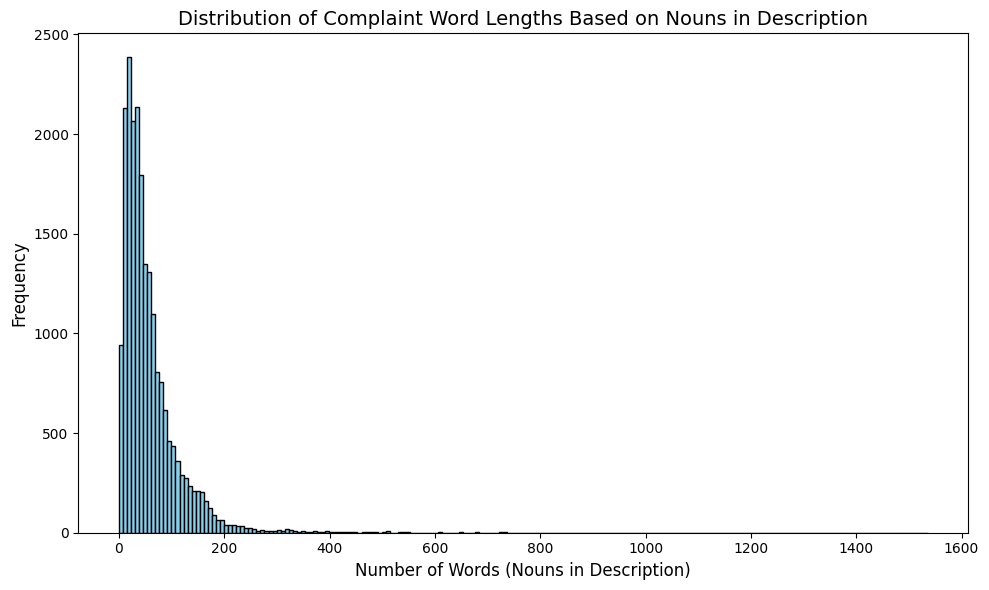

```python
# Visualize the data according to the 'Complaint' word length (based on 'nouns_in_description')
plt.figure(figsize=(10,6))

# Calculate the number of words in each 'nouns_in_description'
word_lens = [len(d.split()) for d in clean_data['cleaned_description']]

# Plot histogram
plt.hist(word_lens, bins=200, color='skyblue', edgecolor='black')

# Add title and labels
plt.title('Distribution of Complaint Word Lengths Based on Nouns in Description', fontsize=14)
plt.xlabel('Number of Words (Nouns in Description)', fontsize=12)
plt.ylabel('Frequency', fontsize=12)

# Display the plot
plt.tight_layout()
plt.show()
```

**Top 40 Most Frequent Words** :

The word cloud will display the top 40 most frequent nouns in the nouns_in_description column, with the size of each word proportional to its frequency. More frequent nouns will appear larger, giving a clear representation of the most common nouns.

```
<wordcloud.wordcloud.WordCloud object at 0x0000023FD0467C10>
```

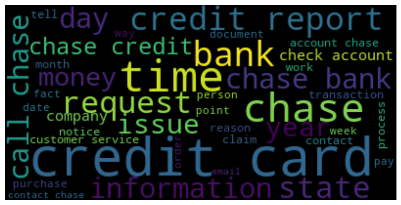

```python
# Ensure stopwords are properly formatted as a set or list
stopwords_set = set(stopwords.words('english'))

# Generate a word cloud using the 'cleaned_description' from the clean_data DataFrame
wordcloud = WordCloud(stopwords=stopwords_set, max_words=40).generate(' '.join(clean_data['cleaned_description']))

# Display the word cloud
print(wordcloud)

# Plot the word cloud with a specified figure size
plt.figure(figsize=(10, 6))
plt.imshow(wordcloud, interpolation='bilinear')
plt.axis('off')  # Hide the axis
plt.show()
```

**Finding the Top Unigrams, Bigrams and Trigrams** :

Identify the most frequent unigrams, bigrams, and trigrams from all the complaints after processing the text.

```python
def get_top_n_ngrams(text, ngram=1, top=30):
    """
    Function to extract the top n unigrams, bigrams, or trigrams based on frequency from the text data.

    Parameters:
    text (list): A list of text documents (e.g., complaint descriptions).
    ngram (int): The size of the n-gram (1 for unigram, 2 for bigram, 3 for trigram).
    top (int): The number of top n-grams to return.

    Returns:
    list: A list of tuples containing n-grams and their frequency.
    """
    # Initialize CountVectorizer with the specified ngram range and stop words
    vec = CountVectorizer(ngram_range=(ngram, ngram), stop_words='english').fit(text)

    # Create a bag-of-words model
    bag_of_words = vec.transform(text)

    # Sum the word frequencies across all documents (rows)
    sum_words = bag_of_words.sum(axis=0)

    # Get the vocabulary and their respective frequencies
    words_freq = [(word, sum_words[0, idx]) for word, idx in vec.vocabulary_.items()]

    # Sort the words by frequency in descending order
    words_freq = sorted(words_freq, key=lambda x: x[1], reverse=True)

    # Return the top n words based on frequency
    return words_freq[:top]

def plot_top_ngrams(ngrams, title):
    """
    Function to plot the top n-grams with their frequencies in a bar chart.

    Parameters:
    ngrams (list): A list of tuples containing n-grams and their frequency.
    title (str): The title of the plot.
    """
    # Convert the top ngrams data into a DataFrame
    df = pd.DataFrame(ngrams, columns=['ngram', 'count'])

    # Plot the top n-grams as a bar chart
    plt.figure(figsize=(12,6))
    fig = sns.barplot(x=df['ngram'], y=df['count'], palette='viridis')
    plt.xticks(rotation=90)  # Rotate x-axis labels for better readability
    plt.title(title, fontsize=16)
    plt.xlabel('N-grams', fontsize=12)
    plt.ylabel('Frequency', fontsize=12)
    plt.tight_layout()  # Adjust layout to avoid clipping
    plt.show()
```

```
Top 10 unigrams words ::  [('chase', 63837), ('account', 44165), ('credit', 33933), ('card', 30255), ('bank', 17560), ('time', 15923), ('charge', 15829), ('payment', 13960), ('check', 12979), ('report', 11913)]
```

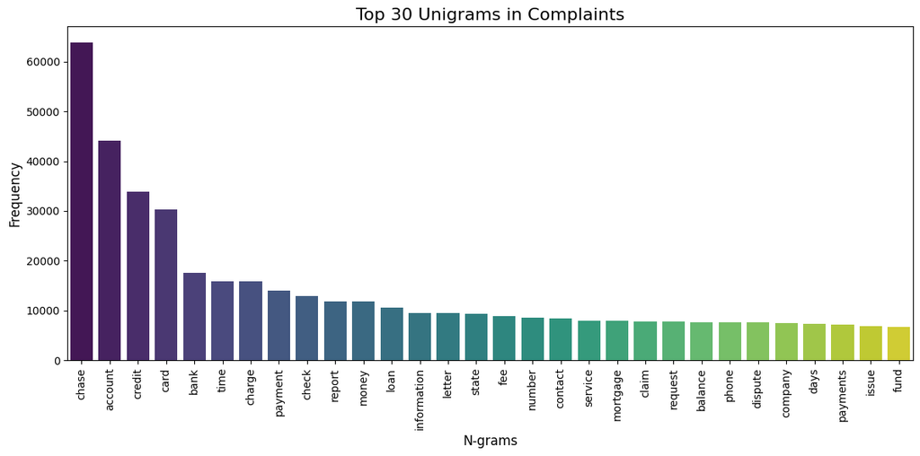

```python
# Get top 30 unigrams and Plot the top 30 unigrams
top_30_unigrams = get_top_n_ngrams(clean_data['cleaned_description'], ngram=1, top=30)
print('Top 10 unigrams words :: ', top_30_unigrams[:10])
plot_top_ngrams(top_30_unigrams, 'Top 30 Unigrams in Complaints')
```

```
Top 10 bigrams words::  [('credit card', 12845), ('credit report', 4937), ('chase bank', 4022), ('chase credit', 3358), ('check account', 3323), ('account chase', 3289), ('customer service', 3029), ('chase account', 2435), ('contact chase', 2175), ('debit card', 1988)]
```

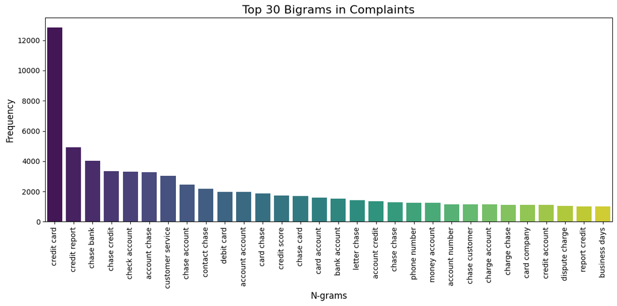

```python
# Get top 30 bigrams and Plot the top 30 bigrams
top_30_bigrams = get_top_n_ngrams(clean_data['cleaned_description'], ngram=2, top=30)
print('Top 10 bigrams words:: ', top_30_bigrams[:10])
plot_top_ngrams(top_30_bigrams, 'Top 30 Bigrams in Complaints')
```

```
Top 10 trigrams words ::  [('chase credit card', 2383), ('credit card account', 1076), ('credit card company', 991), ('credit card chase', 937), ('chase customer service', 639), ('chase check account', 488), ('charge credit card', 449), ('credit card credit', 428), ('account credit card', 362), ('ac…
```

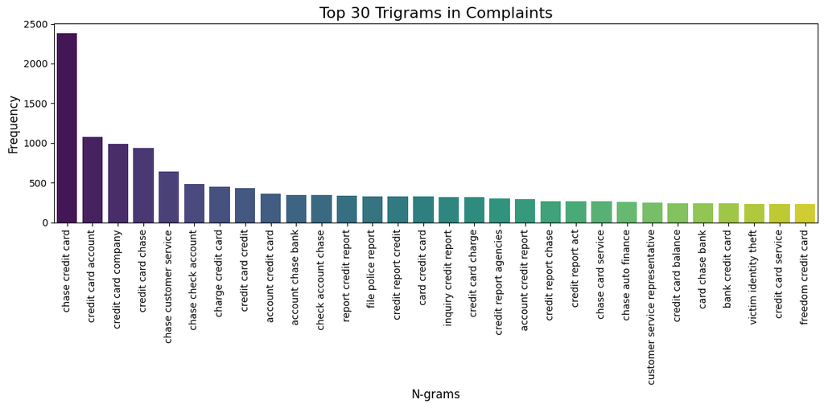

```python
# Get top 30 trigrams and Plot the top 30 trigrams
top_30_trigrams = get_top_n_ngrams(clean_data['cleaned_description'], ngram=3, top=30)
print('Top 10 trigrams words :: ', top_30_trigrams[:10])
plot_top_ngrams(top_30_trigrams, 'Top 30 Trigrams in Complaints')
```

## Step 4. **Feature Extraction**

- Convert the cleaned text into numerical features using techniques like **TF-IDF (Term Frequency-Inverse Document Frequency)** or **Count Vectorization**.
- This step prepares the data for topic modeling and classification.

```python
#Write your code here to initialise the TfidfVectorizer
tfidf = TfidfVectorizer(min_df=2, max_df=0.95, stop_words='english')
```

```python
X_tfidf = tfidf.fit_transform(clean_data['cleaned_description'])
```

```python
print("Total Features :: ", len(tfidf.get_feature_names_out()))
print("-"*50)
print(tfidf.get_feature_names_out())
```

```
Total Features ::  7415
--------------------------------------------------
['aa' 'aaaratings' 'aarp' ... 'zombie' 'zone' 'zoom']
```

## Step 5. **Topic Modelling**

- Apply **Non-Negative Matrix Factorization (NMF)** to uncover latent topics from the text data.
- Analyze the topics to understand the common themes and categorize customer complaints into relevant groups.
- Use the resulting topic clusters to group the tickets into the five predefined categories.

```python
# Topic Modeling using NMF
num_topics = 5
nmf_model = NMF(n_components=num_topics, random_state=40)
W = nmf_model.fit_transform(X_tfidf)
H = nmf_model.components_
```

```python
# Display the top words per topic
words = np.array(tfidf.get_feature_names_out())
for i, topic in enumerate(H):
    print(f"Top words for topic {i}:")
    print(", ".join(words[topic.argsort()[-10:]]))
    print()
```

```
Top words for topic 0:
number, transfer, branch, fund, deposit, chase, bank, money, check, account

Top words for topic 1:
information, company, inquiries, score, account, inquiry, chase, report, card, credit

Top words for topic 2:
document, time, payments, letter, property, home, modification, chase, mortgage, loan

Top words for topic 3:
service, claim, transaction, merchant, purchase, fee, dispute, chase, card, charge

Top words for topic 4:
time, date, auto, statement, pay, month, fee, balance, payments, payment
```

```python
# Assigning topics to the original data
clean_data['topic'] = W.argmax(axis=1)
clean_data.head()
```

|  | cleaned_description | category | topic |
| --- | --- | --- | --- |
| 1 | morning name appreciate chase debt verification statement validate debt mail month attempt debt information consumer chase account advance help | Debt collection, Credit card debt | 2 |
| 2 | upgrade card agent upgrade anniversary date agent information order account change anniversary date consent record agent mislead | Credit card or prepaid card, General-purpose credit card or charge card | 1 |
| 10 | card report application identity consent service etend credit identity applicant | Credit reporting, credit repair services, or other personal consumer reports, Other personal consumer report | 1 |
| 11 | book ticket ticket reward card information offer minute notify screen decision contact refer contact chase notification screen chase representative speak application deny state information offer credi… | Credit reporting, credit repair services, or other personal consumer reports, Credit reporting | 1 |
| 14 | son check deposit chase account fund account money son money chase bank money son chase time call check owner country time date check number claim number chase | Checking or savings account, Checking account | 0 |

```python
# Number of topics (use the number of topics from your NMF model)
N_TOPICS = nmf_model.n_components

# Create column names for the topics and document names
colnames = ["Topic" + str(i) for i in range(N_TOPICS)]
docnames = ["Doc" + str(i) for i in range(len(clean_data))]

# Create the document-topic matrix (rounded to 2 decimal places)
df_doc_topic = pd.DataFrame(np.round(W, 2), columns=colnames, index=docnames)

# Add the 'dominant_topic' column to the DataFrame
df_doc_topic['dominant_topic'] = W.argmax(axis=1)

# Display the result (first few rows)
print(df_doc_topic.head())
```

```
      Topic0  Topic1  Topic2  Topic3  Topic4  dominant_topic
Doc0    0.01    0.01    0.02    0.01    0.01               2
Doc1    0.01    0.01    0.00    0.01    0.00               1
Doc2    0.00    0.06    0.00    0.00    0.00               1
Doc3    0.01    0.06    0.02    0.01    0.00               1
Doc4    0.07    0.00    0.01    0.00    0.00               0
```

```python
clean_data[['cleaned_description', 'category', 'topic']].head()
```

|  | cleaned_description | category | topic |
| --- | --- | --- | --- |
| 1 | morning name appreciate chase debt verification statement validate debt mail month attempt debt information consumer chase account advance help | Debt collection, Credit card debt | 2 |
| 2 | upgrade card agent upgrade anniversary date agent information order account change anniversary date consent record agent mislead | Credit card or prepaid card, General-purpose credit card or charge card | 1 |
| 10 | card report application identity consent service etend credit identity applicant | Credit reporting, credit repair services, or other personal consumer reports, Other personal consumer report | 1 |
| 11 | book ticket ticket reward card information offer minute notify screen decision contact refer contact chase notification screen chase representative speak application deny state information offer credi… | Credit reporting, credit repair services, or other personal consumer reports, Credit reporting | 1 |
| 14 | son check deposit chase account fund account money son money chase bank money son chase time call check owner country time date check number claim number chase | Checking or savings account, Checking account | 0 |

#### **After evaluating the mapping, if the topics assigned are correct then assign these names to the relevant topic:**

- Bank Account services
- Credit card or prepaid card
- Theft/Dispute Reporting
- Mortgage/Loan
- Others

```python
#Create the dictionary of Topic names and Topics
topic_mapping = {
    0: 'Bank Account services',
    1: 'Credit card or prepaid card',
    2: 'Others',
    3: 'Theft/Dispute Reporting',
    4: 'Mortgage/Loan'
}

#Replace Topics with Topic Names
clean_data['topic_mapping'] = clean_data['topic'].map(topic_mapping)
```

```python
# Group the data by 'Topic' and get the first 5 entries for each group
clean_data.groupby('topic').head(5).sort_values(by='topic')
```

|  | cleaned_description | category | topic | topic_mapping |
| --- | --- | --- | --- | --- |
| 14 | son check deposit chase account fund account money son money chase bank money son chase time call check owner country time date check number claim number chase | Checking or savings account, Checking account | 0 | Bank Account services |
| 17 | jp account debit card branch customer service representative account branch remove fund deposit place employment bank associate customer service representative assure fund business day attempt branch … | Checking or savings account, Checking account | 0 | Bank Account services |
| 24 | account chase auto | Vehicle loan or lease, Loan | 0 | Bank Account services |
| 27 | account use code bonus call follow term account deposit bonus days deposit tell account coupon code days bonus | Checking or savings account, Checking account | 0 | Bank Account services |
| 35 | save account bonus bonus auto transfer check savings notice transfer fund check account fund account request team transfer month office resolve concern case | Checking or savings account, Savings account | 0 | Bank Account services |
| 2 | upgrade card agent upgrade anniversary date agent information order account change anniversary date consent record agent mislead | Credit card or prepaid card, General-purpose credit card or charge card | 1 | Credit card or prepaid card |
| 10 | card report application identity consent service etend credit identity applicant | Credit reporting, credit repair services, or other personal consumer reports, Other personal consumer report | 1 | Credit card or prepaid card |
| 11 | book ticket ticket reward card information offer minute notify screen decision contact refer contact chase notification screen chase representative speak application deny state information offer credi… | Credit reporting, credit repair services, or other personal consumer reports, Credit reporting | 1 | Credit card or prepaid card |
| 15 | inquiry | Credit reporting, credit repair services, or other personal consumer reports, Credit reporting | 1 | Credit card or prepaid card |
| 23 | chase credit card data credit report company issue | Credit card or prepaid card, General-purpose credit card or charge card | 1 | Credit card or prepaid card |
| 1 | morning name appreciate chase debt verification statement validate debt mail month attempt debt information consumer chase account advance help | Debt collection, Credit card debt | 2 | Others |
| 81 | pay loan chase title contact chase time resolution time release state registration state title rent car use car | Vehicle loan or lease, Loan | 2 | Others |
| 73 | wire chase branch eact reinstatement amount bank order foreclosure proceedings property chase trustee honor regulations payoff order foreclosure proceedings sales date family resident time reinstateme… | Mortgage, Home equity loan or line of credit (HELOC) | 2 | Others |
| 57 | loan modification chase runaround payments | Mortgage, Conventional home mortgage | 2 | Others |
| 43 | email today title information regard change chase account title ads communications bind arbitration part contract method information consequences people problem chase account chase email mail letter i… | Credit card or prepaid card, General-purpose credit card or charge card | 2 | Others |
| 45 | purchase amount transaction place dispute case bank charge account credit charge charge post credit debt card use bank account activity shock report fraud account dispute place dispute case charge con… | Checking or savings account, Checking account | 3 | Theft/Dispute Reporting |
| 30 | concern charge overdraft fee alert balance unsuficent fee balance transactions chase order charge overdraft fee call guidelines overdrawft bank fault people money document chase refund way place | Checking or savings account, Checking account | 3 | Theft/Dispute Reporting |
| 32 | amazon card decline cater order place brothers funeral amount contact chase noon today number chase savings account user account savings user minutes line call hour contact chase call use card rep tra… | Credit card or prepaid card, General-purpose credit card or charge card | 3 | Theft/Dispute Reporting |
| 21 | payment retailer use chase pay chase website scam website confirmation product response inquiries regard order contact chase information transaction attempt retailers bank contact chase message happen… | Money transfer, virtual currency, or money service, Domestic (US) money transfer | 3 | Theft/Dispute Reporting |
| 40 | sofa love seat table chair debit card charge bank visa claim furniture money | Checking or savings account, Checking account | 3 | Theft/Dispute Reporting |
| 141 | action company date group individuals contact chase claim claim payments creditors credit fund fee transactions claim group individuals payment loan pave claim group individuals payments behalf credit… | Checking or savings account, Checking account | 4 | Mortgage/Loan |
| 58 | purchase payments payment date statement statement purchase balance months statement show purchase statement show balance balance balance difference payment payment require chase purchase balance paym… | Credit card or prepaid card, General-purpose credit card or charge card | 4 | Mortgage/Loan |
| 20 | summer months income employment month payment etension auto loan company chase fours years payment etension grant auto loan payment month payment etension deny year situation supervisor discussion rea… | Vehicle loan or lease, Loan | 4 | Mortgage/Loan |
| 82 | ask credit bureau days payment call info bill owe balance finish bill pay amount day payment day days return payment man phone state payment credit account account charge fee return payment idea think… | Debt collection, Credit card debt | 4 | Mortgage/Loan |
| 167 | payment chase debt cart chase credit card post request days money require pay fee bill payment payee atleast midnight | Checking or savings account, Checking account | 4 | Mortgage/Loan |

#### **Lets check if there is any class imbalance**

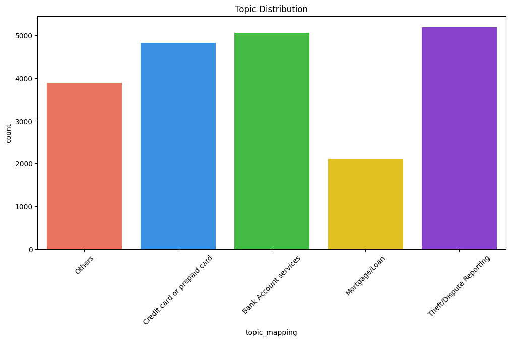

```python
# Define a list of colors for the countplot
colors = ['#FF6347', '#1E90FF', '#32CD32', '#FFD700', '#8A2BE2', '#FF69B4']

# Create the countplot with multi-color pattern
plt.figure(figsize=(12, 6))
sns.countplot(x='topic_mapping', data=clean_data, palette=colors)

# Display the plot
plt.title('Topic Distribution')
plt.xticks(rotation=45)
plt.show()
```

## Step 6. **Model Building Using Supervised Learning**

- Based on the topic modeling results, build a classification model to predict the appropriate department for each customer complaint.
- Choose from algorithms like **Logistic Regression**, **Decision Tree**, or **Random Forest** for model building.

**Apply the supervised models on the training data created. In this process, you have to do the following:**

- Create the vector counts using Count Vectoriser
- Transform the word vecotr to tf-idf
- Create the train & test data using the train_test_split on the tf-idf & topics

```python
#Keep the columns"complaint_what_happened" & "Topic" only in the new dataframe --> training_data
training_data = clean_data[['cleaned_description','topic']]
```

```python
training_data.head()
```

|  | cleaned_description | topic |
| --- | --- | --- |
| 1 | morning name appreciate chase debt verification statement validate debt mail month attempt debt information consumer chase account advance help | 2 |
| 2 | upgrade card agent upgrade anniversary date agent information order account change anniversary date consent record agent mislead | 1 |
| 10 | card report application identity consent service etend credit identity applicant | 1 |
| 11 | book ticket ticket reward card information offer minute notify screen decision contact refer contact chase notification screen chase representative speak application deny state information offer credi… | 1 |
| 14 | son check deposit chase account fund account money son money chase bank money son chase time call check owner country time date check number claim number chase | 0 |

```python
# Assign the 'cleaned_description' and 'topic' columns from the training data to X and y
X = training_data.cleaned_description  # Feature: cleaned descriptions (text)
y = training_data.topic  # Target: topics (labels)

# Initialize the CountVectorizer to convert text data into token counts
count_vect = CountVectorizer()

# Fit and transform the 'cleaned_description' into a document-term matrix (DTM)
X_vect = count_vect.fit_transform(X)

# Initialize the TfidfTransformer to apply Term Frequency-Inverse Document Frequency (TF-IDF) transformation
tfidf_transformer = TfidfTransformer()

# Fit and transform the DTM to obtain the TF-IDF representation of the text data
X_tfidf = tfidf_transformer.fit_transform(X_vect)
```

```python
# Split the data into training and testing sets
# X_tfidf: The transformed feature data (TF-IDF)
# y: The target variable (topics/labels)
# test_size=0.25: 25% of the data will be used for testing, and the rest (75%) will be used for training
# random_state=40: A seed for random number generation, ensuring reproducibility of the split
# stratify=y: Ensures that the class distribution in the target variable (y) is preserved in both training and testing sets

X_train, X_test, y_train, y_test = train_test_split(X_tfidf, y, test_size=0.25, random_state=40, stratify=y)
```

## Step 7. **Model Training and Evaluation**

- Split the dataset into training and testing sets.
- Train the model using the training set and evaluate its performance on the testing set using metrics such as accuracy, precision, recall, and F1 score.

#### **We are trying the following models** -

- Logistic regression
- Decision Tree
- Random Forest
- Naive Bayes (optional)

**Using the required evaluation metrics judge the tried models and select the ones performing the best**

```python
# Function to save model
def save_model(model, model_name):
    joblib.dump(model, f"{model_name}.pkl")
    print(f"Model {model_name} saved as {model_name}.pkl")

# Function to print classification report
def print_classification_report(model_name, y_true, y_pred):
    print(f"Classification Report for {model_name}:")
    print(classification_report(y_true, y_pred))

# Function to plot ROC curve (updated for multiclass classification)
def plot_roc_curve(model_name, y_train, y_test, train_preds_prob, test_preds_prob, n_classes):
    # Binarize the outputs for multiclass
    y_train_bin = label_binarize(y_train, classes=[i for i in range(n_classes)])
    y_test_bin = label_binarize(y_test, classes=[i for i in range(n_classes)])

    # Prepare the ROC curve for each class
    plt.figure(figsize=(12, 6))

    # ROC curve for each class
    for i in range(n_classes):
        fpr_train, tpr_train, _ = roc_curve(y_train_bin[:, i], train_preds_prob[:, i])
        fpr_test, tpr_test, _ = roc_curve(y_test_bin[:, i], test_preds_prob[:, i])

        roc_auc_train = auc(fpr_train, tpr_train)
        roc_auc_test = auc(fpr_test, tpr_test)

        # Plot ROC curve for train and test
        plt.subplot(1, 2, 1)
        plt.plot(fpr_train, tpr_train, lw=2, label=f'Class {i} Train ROC (area = {roc_auc_train:.2f})')

        plt.subplot(1, 2, 2)
        plt.plot(fpr_test, tpr_test, lw=2, label=f'Class {i} Test ROC (area = {roc_auc_test:.2f})')

    # Add some plot details
    plt.subplot(1, 2, 1)
    plt.plot([0, 1], [0, 1], color='gray', linestyle='--', lw=2)
    plt.title(f'ROC Curve - {model_name} (Train)')
    plt.xlabel('False Positive Rate')
    plt.ylabel('True Positive Rate')
    plt.legend(loc='lower right')

    plt.subplot(1, 2, 2)
    plt.plot([0, 1], [0, 1], color='gray', linestyle='--', lw=2)
    plt.title(f'ROC Curve - {model_name} (Test)')
    plt.xlabel('False Positive Rate')
    plt.ylabel('True Positive Rate')
    plt.legend(loc='lower right')

    plt.tight_layout()
    plt.show()

# Function to plot confusion matrix
def plot_confusion_matrix(model_name, y_train, y_test, train_preds, test_preds):
    # Confusion matrix for train and test sets
    cm_train = confusion_matrix(y_train, train_preds)
    cm_test = confusion_matrix(y_test, test_preds)

    # Plot confusion matrix for train set
    plt.figure(figsize=(12, 6))
    plt.subplot(1, 2, 1)
    sns.heatmap(cm_train, annot=True, fmt='d', cmap='Blues', cbar=False, xticklabels=['Class 0', 'Class 1'], yticklabels=['Class 0', 'Class 1'])
    plt.title(f'Confusion Matrix - {model_name} (Train)')
    plt.xlabel('Predicted')
    plt.ylabel('True')

    # Plot confusion matrix for test set
    plt.subplot(1, 2, 2)
    sns.heatmap(cm_test, annot=True, fmt='d', cmap='Blues', cbar=False, xticklabels=['Class 0', 'Class 1'], yticklabels=['Class 0', 'Class 1'])
    plt.title(f'Confusion Matrix - {model_name} (Test)')
    plt.xlabel('Predicted')
    plt.ylabel('True')

    plt.tight_layout()
    plt.show()
```

```
--------------------------------------------------
________ Multinomial Naive Bayes ________
--------------------------------------------------
Performing GridSearchCV for Multinomial Naive Bayes...
Fitting 5 folds for each of 5 candidates, totalling 25 fits
Best parameters for Multinomial Naive Bayes: {'alpha': 0.1}
Best cross-validation score for Multinomial Naive Bayes: 0.789483259183322

Classification Report for Multinomial Naive Bayes:
              precision    recall  f1-score   support

           0       0.80      0.86      0.83      1265
           1       0.78      0.81      0.79      1206
           2       0.84      0.86      0.85       973
           3       0.78      0.83      0.80      1298
           4       0.81      0.45      0.58       526

    accuracy                           0.80      5268
   macro avg       0.80      0.76      0.77      5268
weighted avg       0.80      0.80      0.79      5268

Model Multinomial Naive Bayes saved as Multinomial Naive Bayes.pkl
Training accuracy for Multinomial Naive Bayes: 0.8692
Test accuracy for Multinomial Naive Bayes: 0.7984
```

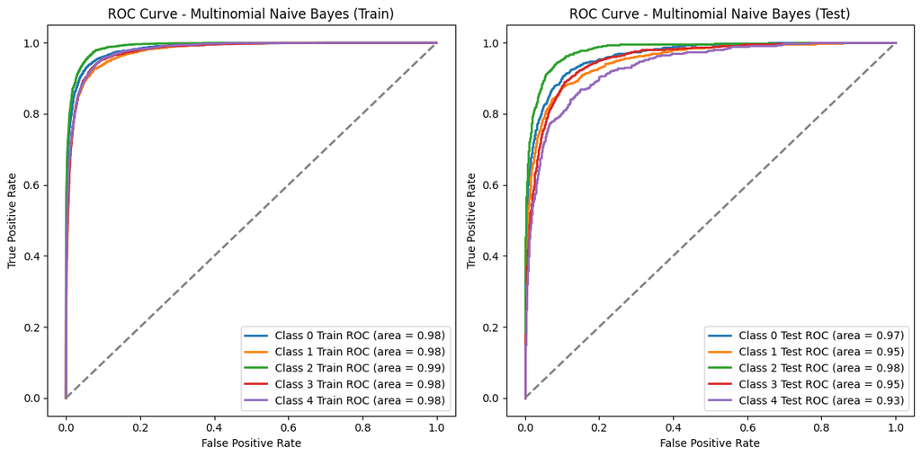

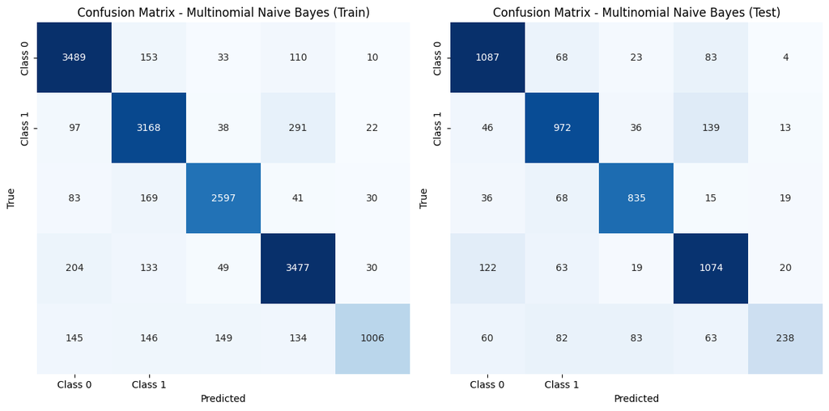

```
--------------------------------------------------
________ Logistic Regression ________
--------------------------------------------------
Performing GridSearchCV for Logistic Regression...
Fitting 5 folds for each of 18 candidates, totalling 90 fits
Best parameters for Logistic Regression: {'C': 10, 'penalty': 'l1', 'solver': 'saga'}
Best cross-validation score for Logistic Regression: 0.9735510914267638

Classification Report for Logistic Regression:
              precision    recall  f1-score   support

           0       0.98      0.98      0.98      1265
           1       0.98      0.99      0.98      1206
           2       0.97      0.98      0.98       973
           3       0.97      0.97      0.97      1298
           4       0.98      0.95      0.97       526

    accuracy                           0.98      5268
   macro avg       0.98      0.97      0.97      5268
weighted avg       0.98      0.98      0.98      5268

Model Logistic Regression saved as Logistic Regression.pkl
Training accuracy for Logistic Regression: 0.9997
Test accuracy for Logistic Regression: 0.9757
```

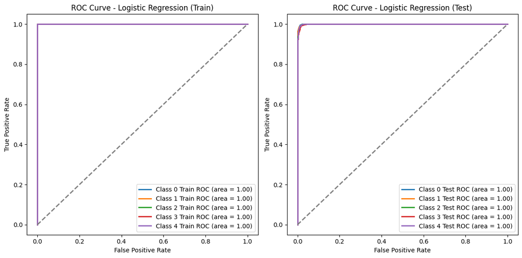

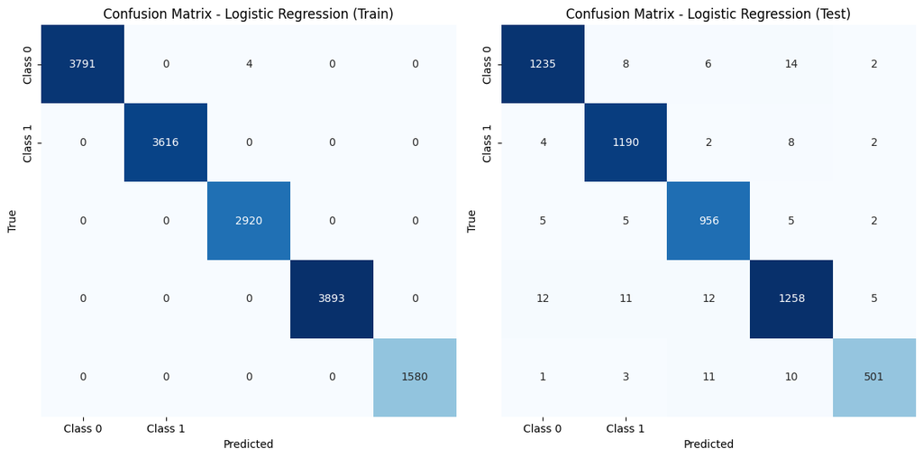

```
--------------------------------------------------
________ Decision Tree Classifier ________
--------------------------------------------------
Performing GridSearchCV for Decision Tree Classifier...
Fitting 5 folds for each of 4 candidates, totalling 20 fits
Best parameters for Decision Tree Classifier: {'max_depth': 30, 'min_samples_leaf': 5}
Best cross-validation score for Decision Tree Classifier: 0.8222598600827331

Classification Report for Decision Tree Classifier:
              precision    recall  f1-score   support

           0       0.83      0.87      0.85      1265
           1       0.85      0.84      0.85      1206
           2       0.83      0.86      0.85       973
           3       0.83      0.82      0.82      1298
           4       0.79      0.71      0.75       526

    accuracy                           0.83      5268
   macro avg       0.83      0.82      0.82      5268
weighted avg       0.83      0.83      0.83      5268

Model Decision Tree Classifier saved as Decision Tree Classifier.pkl
Training accuracy for Decision Tree Classifier: 0.9177
Test accuracy for Decision Tree Classifier: 0.8320
```

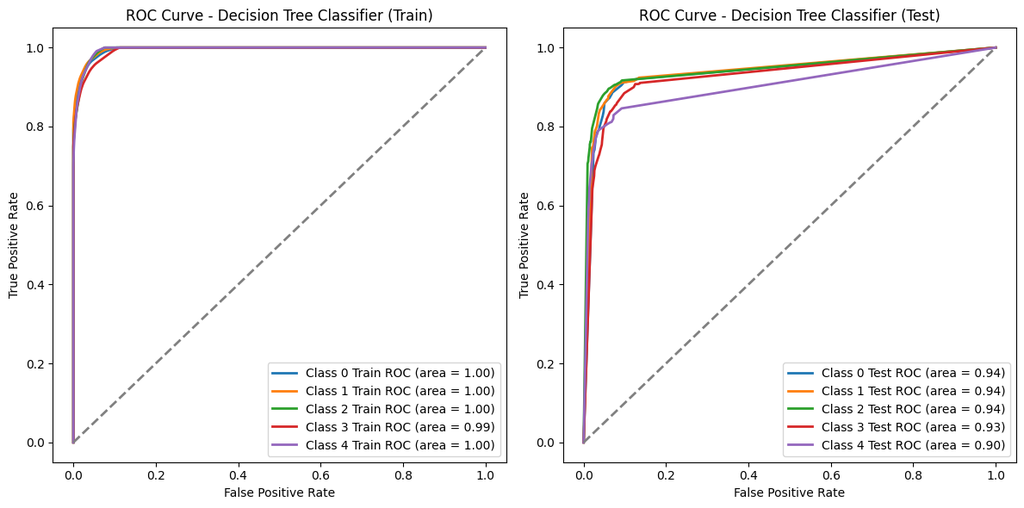

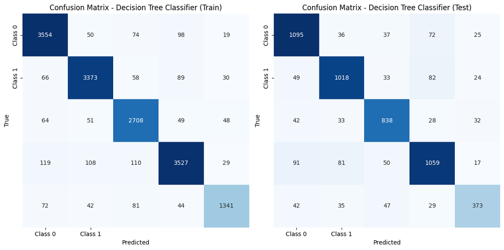

```
--------------------------------------------------
________ Random Forest Classifier ________
--------------------------------------------------
Performing GridSearchCV for Random Forest Classifier...
Fitting 5 folds for each of 8 candidates, totalling 40 fits
Best parameters for Random Forest Classifier: {'max_depth': 30, 'min_samples_leaf': 5, 'n_estimators': 200}
Best cross-validation score for Random Forest Classifier: 0.8089090938214554

Classification Report for Random Forest Classifier:
              precision    recall  f1-score   support

           0       0.79      0.93      0.85      1265
           1       0.79      0.88      0.83      1206
           2       0.85      0.88      0.86       973
           3       0.80      0.84      0.82      1298
           4       0.99      0.14      0.25       526

    accuracy                           0.81      5268
   macro avg       0.84      0.73      0.72      5268
weighted avg       0.82      0.81      0.78      5268

Model Random Forest Classifier saved as Random Forest Classifier.pkl
Training accuracy for Random Forest Classifier: 0.8569
Test accuracy for Random Forest Classifier: 0.8071
```

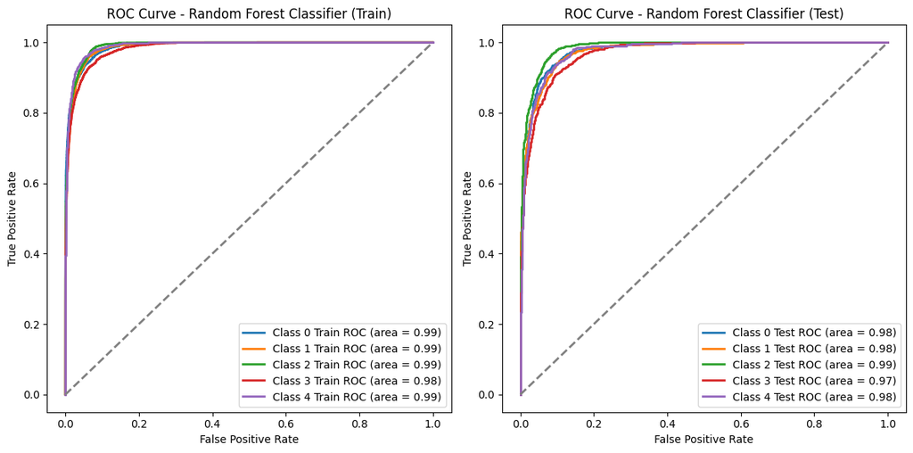

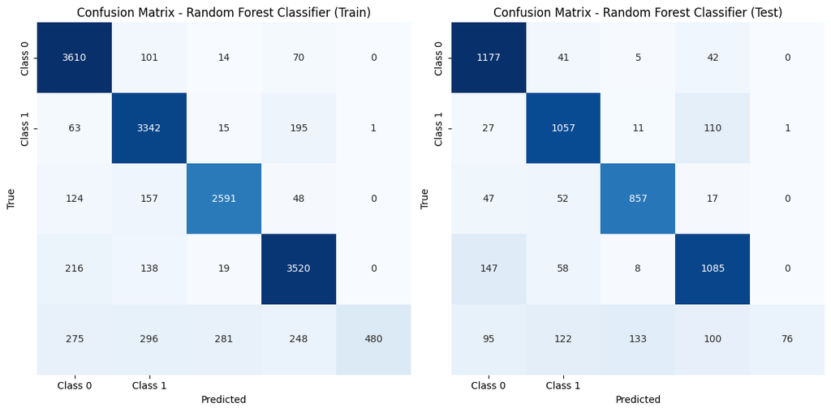

```python
# Initialize the classifiers (as before)
mnb = MultinomialNB()
log_reg = LogisticRegression(max_iter=1000)
dtc = DecisionTreeClassifier(random_state=40)
rfc = RandomForestClassifier(random_state=40, n_jobs=-1, oob_score=True)

# Hyperparameters for each classifier (as before)
mnb_params = { 'alpha': [1, 0.1, 0.01, 0.001, 0.0001] }
log_params = { 'C': [0.01, 1, 10], 'penalty': ['l1', 'l2'], 'solver': ['liblinear', 'newton-cg', 'saga'] }
dtc_params = { 'max_depth': [20, 30], 'min_samples_leaf': [5, 10] }
rfc_params = { 'max_depth': [20, 30], 'min_samples_leaf': [5, 10], 'n_estimators': [100, 200] }

# Dictionary for model hyperparameter tuning with GridSearchCV (as before)
tuned_models = {
    "Multinomial Naive Bayes": (mnb, mnb_params),
    "Logistic Regression": (log_reg, log_params),
    "Decision Tree Classifier": (dtc, dtc_params),
    "Random Forest Classifier": (rfc, rfc_params)
}

# Dictionary to store grid search results
grid_search_results = {}

# DataFrame to store metrics
metrics_df = pd.DataFrame(columns=["Model", "Train Accuracy", "Test Accuracy"])

# Loop through each model and perform GridSearchCV
for model_name, (model, params) in tuned_models.items():
    print("-"*50)
    print(f"________ {model_name} ________")
    print("-"*50)
    print(f"Performing GridSearchCV for {model_name}...")

    # Initialize GridSearchCV with 5-fold cross-validation
    grid_search = GridSearchCV(estimator=model, param_grid=params, cv=5, n_jobs=-1, verbose=1)

    # Fit the model to the training data
    grid_search.fit(X_train, y_train)

    # Store the results in the dictionary
    grid_search_results[model_name] = grid_search

    # Display the best parameters and best score from cross-validation
    print(f"Best parameters for {model_name}: {grid_search.best_params_}")
    print(f"Best cross-validation score for {model_name}: {grid_search.best_score_}\n")

    # Get the best model from GridSearchCV
    best_model = grid_search.best_estimator_
    best_model

    # Predict on the training data and calculate accuracy
    train_preds = best_model.predict(X_train)
    train_accuracy = accuracy_score(y_train, train_preds)

    # Predict on the test data and calculate accuracy
    test_preds = best_model.predict(X_test)
    test_accuracy = accuracy_score(y_test, test_preds)

    # Get probabilities for ROC curve (multiclass)
    train_preds_prob = best_model.predict_proba(X_train)
    test_preds_prob = best_model.predict_proba(X_test)

    # Print classification report
    print_classification_report(model_name, y_test, test_preds)

    # Save the model
    save_model(best_model, model_name)

    # Append the results to the DataFrame using pd.concat
    metrics_df = pd.concat([metrics_df, pd.DataFrame([{
        "Model": model_name,
        "Train Accuracy": train_accuracy,
        "Test Accuracy": test_accuracy
    }])], ignore_index=True)

    print(f"Training accuracy for {model_name}: {train_accuracy:.4f}")
    print(f"Test accuracy for {model_name}: {test_accuracy:.4f}\n")

    # Plot ROC Curve
    plot_roc_curve(model_name, y_train, y_test, train_preds_prob, test_preds_prob, n_classes=len(set(y_train)))

    # Plot Confusion Matrix
    plot_confusion_matrix(model_name, y_train, y_test, train_preds, test_preds)
```

```python
# Print the DataFrame with metrics
print("All models' train and test metrics:")
metrics_df
```

```
All models' train and test metrics:
```

|  | Model | Train Accuracy | Test Accuracy |
| --- | --- | --- | --- |
| 0 | Multinomial Naive Bayes | 0.869210 | 0.798405 |
| 1 | Logistic Regression | 0.999747 | 0.975702 |
| 2 | Decision Tree Classifier | 0.917679 | 0.832005 |
| 3 | Random Forest Classifier | 0.856935 | 0.807137 |

## Step 8. **Model Inference**

- Once the model is trained and evaluated, use it to classify new customer complaint tickets automatically.
- Test the model's ability to generalize to unseen data and ensure its practical applicability in real-world scenarios.

```python
# Access the second model (Logistic Regression) from the grid_search_results dictionary
second_model_name = "Logistic Regression"
second_grid_search = grid_search_results[second_model_name]

# Access the best parameters for the second model
best_params_second_model = second_grid_search.best_params_
print(f"Best parameters for {second_model_name}: {best_params_second_model}")

# Access the best model (best estimator) for the second model
best_model_second_model = second_grid_search.best_estimator_
print(f"Best model for {second_model_name}: {best_model_second_model}")

# Access the cross-validation score for the second model
best_score_second_model = second_grid_search.best_score_
print(f"Best cross-validation score for {second_model_name}: {best_score_second_model}")

# # Use the best estimator (model) from GridSearchCV to make predictions on the test data
# predicted_topics_second_model = second_grid_search.best_estimator_.predict(test_tfidf)

# # Output the predicted topics
# print(predicted_topics_second_model)
```

```
Best parameters for Logistic Regression: {'C': 10, 'penalty': 'l1', 'solver': 'saga'}
Best model for Logistic Regression: LogisticRegression(C=10, max_iter=1000, penalty='l1', solver='saga')
Best cross-validation score for Logistic Regression: 0.9735510914267638
```

```python
# Sample test complaints for each category
test_complaints = [
    # Bank Account Services
    'I encountered an issue accessing my savings account online. The page keeps freezing.',
    'I have been trying to make a transfer from my checking account, but it keeps getting rejected.',

    # Credit Card or Prepaid Card
    'I have been charged interest on my credit card even though I paid off my balance in full.',
    'I tried to increase my credit limit but my request was denied. Can someone explain why?',

    # Theft/Dispute Reporting
    'I tried to dispute a charge for a product I didn’t receive, but the process is unclear.',
    'I was charged for an item I returned. I would like to dispute the transaction.',

    # Mortgage/Loan
    'I was charged a late fee for my mortgage even though I made my payment on time.',
    'I was told my mortgage payment would decrease, but it has increased significantly.',

    # Others
    'I was told I would receive a callback, but I never did. Can you help me with my issue?',
    'I requested an appointment and was told I would be notified, but I haven’t received any updates.'
]

# Actual topics (these are the true labels for the complaints, which you can compare with predictions)
actual_topics = [
    'Bank Account Services', 'Bank Account Services',
    'Credit Card or Prepaid Card', 'Credit Card or Prepaid Card',
    'Theft/Dispute Reporting', 'Theft/Dispute Reporting',
    'Mortgage/Loan', 'Mortgage/Loan',
    'Others','Others'
]

# Assuming the following variables are already defined:
# - count_vect: CountVectorizer that is already fitted to the training data
# - tfidf_transformer: TfidfTransformer that is already fitted to the training data
# - grid_search_log: A trained model (e.g., a GridSearchCV model with the best estimator)
# - topic_mapping: A dictionary mapping predicted index to topic name

# Vectorize the test complaints and apply tf-idf transformation
test_vectorized = count_vect.transform(test_complaints)  # Count vectorization
test_tfidf = tfidf_transformer.transform(test_vectorized)  # TF-IDF transformation

# Predict the topics based on the test complaints
predicted_topics = second_grid_search.best_estimator_.predict(test_tfidf)

# Display the actual and predicted topics
for complaint, actual, prediction in zip(test_complaints, actual_topics, predicted_topics):
    predicted_topic = topic_mapping[prediction]  # Map index to the actual topic
    print(f"Complaint: {complaint}")
    print(f"Actual Topic: {actual}")
    print(f"Predicted Topic: {predicted_topic}")
    print('-' * 50)
```

```
Complaint: I encountered an issue accessing my savings account online. The page keeps freezing.
Actual Topic: Bank Account Services
Predicted Topic: Bank Account services
--------------------------------------------------
Complaint: I have been trying to make a transfer from my checking account, but it keeps getting rejected.
Actual Topic: Bank Account Services
Predicted Topic: Bank Account services
--------------------------------------------------
Complaint: I have been charged interest on my credit card even though I paid off my balance in full.
Actual Topic: Credit Card or Prepaid Card
Predicted Topic: Credit card or prepaid card
--------------------------------------------------
Complaint: I tried to increase my credit limit but my request was denied. Can someone explain why?
Actual Topic: Credit Card or Prepaid Card
Predicted Topic: Credit card or prepaid card
--------------------------------------------------
Complaint: I tried to dispute a charge for a product I didn’t receive, but the process is unclear.
Actual Topic: Theft/Dispute Reporting
Predicted Topic: Theft/Dispute Reporting
--------------------------------------------------
Complaint: I was charged for an item I returned. I would like to dispute the transaction.
Actual Topic: Theft/Dispute Reporting
Predicted Topic: Theft/Dispute Reporting
--------------------------------------------------
Complaint: I was charged a late fee for my mortgage even though I made my payment on time.
Actual Topic: Mortgage/Loan
Predicted Topic: Mortgage/Loan
--------------------------------------------------
Complaint: I was told my mortgage payment would decrease, but it has increased significantly.
Actual Topic: Mortgage/Loan
Predicted Topic: Mortgage/Loan
--------------------------------------------------
Complaint: I was told I would receive a callback, but I never did. Can you help me with my issue?
Actual Topic: Others
Predicted Topic: Others
--------------------------------------------------
Complaint: I requested an appointment and was told I would be notified, but I haven’t received any updates.
Actual Topic: Others
Predicted Topic: Others
--------------------------------------------------
```

## Conclusion 🏁📊

Based on these results, **Logistic Regression** is the best choice for automating the classification of customer complaints, offering high accuracy and strong generalization capabilities. 📈💡

By implementing this model, the company can streamline its customer support process, improve the accuracy of complaint routing, and ultimately boost customer satisfaction. 🎉👏

### Next Steps:

- Further fine-tuning of the Logistic Regression model could be explored to improve its performance even more.
- Real-time integration of the model into the company’s ticketing system will be crucial for immediate impact. 🔧🚀